# Klasifikasi dan Diskriminan

Antonito HC

January 17, 2019

```
#Deskripsi Data
```

Data yang digunakan adalah data sekunder yang diambil yang diambil dari Badan Pusat Satistik(BPS)mengenai jumlah pencari kerja, Migrasi dan lapangan kerja pada 9 sektor di Indonesia

```r
setwd("E:/ADI BUANA/DSC")
data1 <- read.csv("evaluasi.csv")
namapro <- read.csv("prov.csv")
rownames(data1) <- namapro$propinsi
```

### Data Set

```r
library(DT)
datatable(data1)
```

|  | Pencari.kerja.laki.laki | pencari.kerja.perempuan | Migrasi.Tahun.2015 | pertanian | PertambanganPenggalian | IndustriPengolahan | ListrikGasAirBersih | BangunanKonstruksi | PerdaganganHotelRestoran | Pengangkutan | BankLembagaKeuangan | Jasajasa |
| --- | --- | --- | --- | --- | --- | --- | --- | --- | --- | --- | --- | --- |
| Aceh | 4941 | 7687 | 209815 | 1694085 | 2249514 | 1442031 | 2598854 | 1815986 | 1664014 | 2124586 | 2331218 | 2507836 |
| Sumatera Utara | 3464 | 5370 | 519843 | 1689782 | 1668645 | 1806080 | 2343467 | 2086754 | 1534915 | 1897080 | 2451088 | 2318491 |
| Sumatera Barat | 1773 | 2361 | 358123 | 2245736 | 2281318 | 1635646 | 2077083 | 2055218 | 1585139 | 2058409 | 2597639 | 2773917 |
| Riau | 10497 | 13126 | 1881079 | 2292903 | 3589274 | 2544934 | 3518307 | 2347499 | 1803739 | 2302266 | 3084036 | 2734812 |
| Jambi | 6931 | 5469 | 710428 | 1379110 | 2486343 | 2177920 | 3892010 | 2466180 | 2451040 | 1900725 | 2515017 | 2219156 |
| Sumatera Selatan | 13635 | 9020 | 966060 | 1175301 | 2708060 | 2385103 | 3760132 | 1932539 | 1736979 | 2512560 | 3033189 | 2612740 |
| Bengkulu | 9693 | 7216 | 337041 | 1587525 | 1776920 | 1041120 | 0 | 1812601 | 1375089 | 2076278 | 2316649 | 2557546 |
| Lampung | 5317 | 5498 | 1362387 | 1395164 | 1500000 | 1727757 | 2258916 | 1849281 | 1387297 | 2431567 | 2213427 | 2155252 |
| Kepulauan Babel | 4280 | 5905 | 192729 | 1922626 | 2071224 | 2460984 | 2899579 | 2606223 | 2002412 | 1890263 | 2672603 | 2859604 |
| Kepulauan Riau | 16404 | 28445 | 881035 | 2173905 | 5025958 | 4465721 | 3600000 | 2939013 | 2475628 | 3145406 | 3300149 | 3053899 |

[output cut: 24 more lines]

Variabel yang digunakan adalah sebagai berikut

| Variabel | Keterangan |
| --- | --- |
| X1 | Pencari Kerja Laki-laki |
| X2 | Pencari Kerja Perempuan |
| X3 | Migrasi tahun 2015 |
| X4 | Pertanian |
| X5 | Pertambangan Penggalian |
| X6 | Industri Pengolahan |
| X7 | Listrik Gas Air Bersih |
| X8 | Bangunan Konstruksi |
| X9 | Perdagangan Hotel Restoran |
| X10 | Pengangkutan |
| X11 | BankLembaga Keuangan |
| X12 | Jasajasa |

#### Rename Nama Variabel untuk memudahkan dalam analisis

```r
colnames(data1) <- c('X1', 'X2', 'X3', 'X4',
                     'X5', 'X6', 'X7', 'X8',
                     'X9', 'X10', 'X11', 'X12')
```

#### Explorasi data ringkasan 5 numerik data (Summary)

```r
summary(data1)
```

```
##        X1               X2               X3                X4
##  Min.   :     0   Min.   :     0   Min.   :  64448   Min.   : 963277
##  1st Qu.:  3553   1st Qu.:  4357   1st Qu.: 197000   1st Qu.:1555229
##  Median :  7100   Median :  7452   Median : 454608   Median :1847186
##  Mean   : 23224   Mean   : 22644   Mean   : 796676   Mean   :1865750
##  3rd Qu.: 16383   3rd Qu.: 17395   3rd Qu.: 913373   3rd Qu.:2208455
##  Max.   :115266   Max.   :210462   Max.   :4961541   Max.   :2944656
##        X5                 X6                X7                X8
##  Min.   :       0   Min.   :1041120   Min.   :      0   Min.   :1310325
##  1st Qu.: 2115796   1st Qu.:1638041   1st Qu.:2346790   1st Qu.:1934089
##  Median : 3184834   Median :2080142   Median :3137029   Median :2256270
##  Mean   : 3574686   Mean   :2245063   Mean   :3090744   Mean   :2342050
##  3rd Qu.: 4312053   3rd Qu.:2635551   3rd Qu.:3849000   3rd Qu.:2622409
##  Max.   :10384106   Max.   :4465721   Max.   :6245637   Max.   :3854428
##        X9               X10               X11               X12
##  Min.   :1339405   Min.   :1460243   Min.   :1672844   Min.   :2155252
##  1st Qu.:1526201   1st Qu.:2019320   1st Qu.:2464116   1st Qu.:2468391
##  Median :1744982   Median :2311908   Median :2697896   Median :2731324
##  Mean   :1943995   Mean   :2546489   Mean   :2893575   Mean   :2772362
##  3rd Qu.:2213226   3rd Qu.:2952537   3rd Qu.:3071324   3rd Qu.:3044146
##  Max.   :3684859   Max.   :4599861   Max.   :5810807   Max.   :3952291
```

#### Standarisasi data

Standarisasi dilakukan untuk menghindari varians yang tinggi

```r
df <- scale(data1)
head(df)
```

```
##                          X1         X2          X3         X4           X5
## Aceh             -0.5217856 -0.3616116 -0.56143456 -0.4071721 -0.564604851
## Sumatera Utara   -0.5639388 -0.4176289 -0.26483887 -0.4173784 -0.812090858
## Sumatera Barat   -0.6121996 -0.4903765 -0.41955217  0.9012864 -0.551054386
## Riau             -0.3632185 -0.2301148  1.03742005  1.0131616  0.006215513
## Jambi            -0.4649914 -0.4152354 -0.08251118 -1.1542599 -0.463701095
## Sumatera Selatan -0.2736606 -0.3293842  0.16204528 -1.6376735 -0.369235983
##                           X6         X7         X8         X9         X10
## Aceh             -0.95371569 -0.3684234 -0.9662708 -0.4851861 -0.51094900
## Sumatera Utara   -0.52135549 -0.5597070 -0.4689256 -0.7089048 -0.78647177
## Sumatera Barat   -0.72377022 -0.7592272 -0.5268508 -0.6218705 -0.59109313
## Riau              0.35613920  0.3202421  0.0100094 -0.2430533 -0.29576837
## Jambi            -0.07974236  0.6001437  0.2280020  0.8786699 -0.78205747
## Sumatera Selatan  0.16631706  0.5013678 -0.7521869 -0.3587433 -0.04109031
##                         X11          X12
## Aceh             -0.7012148 -0.592564801
## Sumatera Utara   -0.5517465 -1.016716801
## Sumatera Barat   -0.3690090  0.003483621
## Riau              0.2374894 -0.084115544
## Jambi            -0.4720321 -1.239237274
## Sumatera Selatan  0.1740872 -0.357569203
```

# K-Means Cluster

K-means Cluster merupakan salah satu metode non hirarki. Dalam kasus ini telah ditentukan jumlah klaster yang akan ditentukan. Jumlah klaster dalam kasus ini sebanyak 3

Berikut adalah library yang digunakan dalam K-means cluster

```r
library(cluster)
library(dendextend)
library(factoextra)
```

#### Penentuan jumlah klaster

```r
set.seed(123)
km <- kmeans(df, 3, nstart = 25)
print(km)
```

```
## K-means clustering with 3 clusters of sizes 6, 4, 24
##
## Cluster means:
##            X1          X2         X3         X4         X5         X6
## 1 -0.07019083  0.01273162  0.6443143  1.0264402  0.9519319  1.6900302
## 2  2.28041587  2.22157315  0.9712086 -0.8586002  0.8271653 -0.2092741
## 3 -0.36252160 -0.37344509 -0.3229467 -0.1135100 -0.3758439 -0.3876285
##           X7         X8         X9        X10        X11        X12
## 1  0.5745340  1.5340996  1.6787512  1.1172408  1.2838302  1.5175361
## 2  0.2447049 -0.3050840 -0.3072993  0.9148864  0.4568342 -0.6234043
## 3 -0.1844176 -0.3326776 -0.3684712 -0.4317913 -0.3970966 -0.2754833
##
## Clustering vector:
##               Aceh     Sumatera Utara     Sumatera Barat
##                  3                  3                  3
##               Riau              Jambi   Sumatera Selatan
##                  3                  3                  3
##           Bengkulu            Lampung    Kepulauan Babel
##                  3                  3                  3
##     Kepulauan Riau        DKI Jakarta         Jawa Barat
##                  1                  1                  2
##        Jawa Tengah                DIY         Jawa Timur
##                  2                  3                  2
##             Banten               Bali            Nusa TB
##                  1                  3                  3
##            Nusa TT   Kalimantan Barat  Kalimantan Tengah
##                  3                  3                  3
## Kalimantan Selatan   Kalimantan Timur   Kalimantan Utara
##                  3                  1                  1
##     Sulawesi Utara    Sulawesi Tengah   Sulawesi Selatan
##                  3                  3                  2
##  Sulawesi Tenggara          Gorontalo     Sulawesi Barat
##                  3                  3                  3
##             Maluku       Maluku Utara        Papua Barat
##                  3                  3                  3
##              Papua
##                  1
##
## Within cluster sum of squares by cluster:
## [1]  46.35354  40.12967 123.86827
##  (between_SS / total_SS =  46.9 %)
##
## Available components:
##
## [1] "cluster"      "centers"      "totss"        "withinss"
## [5] "tot.withinss" "betweenss"    "size"         "iter"
## [9] "ifault"
```

Berdasarkan Output diatas dalam dilihat bahwa jumlah klaster yang dibentuk sebanayak 3 klaster. Klaster 1 memiliki 6 anggota, klaster 2 memilki 4 anggota sedangkan klaster memiliki 24 anggota. untuk mengetahui masing-masing anggota klaster dapat dilihat pada visualisasi dibawah ini.

#### Visualisasi anggota klaster

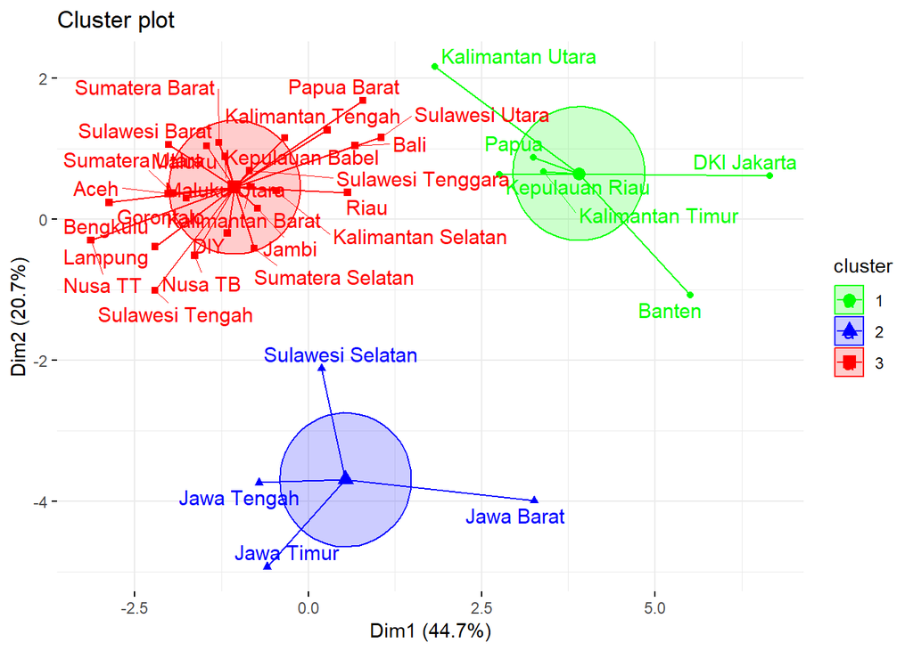

```r
fviz_cluster(km, data = df,
             palette = c("green", "blue", "red"),
             ellipse.type = "euclid", # Concentration ellipse
             star.plot = T, # Add segments from centroids to items
             repel = T, # Avoid label overplotting (slow)
             ggtheme = theme_minimal()
)
```

Dari visualisasi diatas dapat dilihat bahwa anggota pada klaster pertama adalah DKI Jakarta, Banten, Kalimantan Timur, Kalimantan Utara, Kepulauan Riau dan Papua. Untuk anggota Klaster, anggotanya adalah Jawa Tengah, Jawa Timur, Jawa Barat dan Sulawesi Selatan. Sedangkan sisanya masuk dalam klaster ketiga.

```r
data.baru1 <- cbind(df, cluster=km$cluster)
head(data.baru1)
```

```
##                          X1         X2          X3         X4           X5
## Aceh             -0.5217856 -0.3616116 -0.56143456 -0.4071721 -0.564604851
## Sumatera Utara   -0.5639388 -0.4176289 -0.26483887 -0.4173784 -0.812090858
## Sumatera Barat   -0.6121996 -0.4903765 -0.41955217  0.9012864 -0.551054386
## Riau             -0.3632185 -0.2301148  1.03742005  1.0131616  0.006215513
## Jambi            -0.4649914 -0.4152354 -0.08251118 -1.1542599 -0.463701095
## Sumatera Selatan -0.2736606 -0.3293842  0.16204528 -1.6376735 -0.369235983
##                           X6         X7         X8         X9         X10
## Aceh             -0.95371569 -0.3684234 -0.9662708 -0.4851861 -0.51094900
## Sumatera Utara   -0.52135549 -0.5597070 -0.4689256 -0.7089048 -0.78647177
## Sumatera Barat   -0.72377022 -0.7592272 -0.5268508 -0.6218705 -0.59109313
## Riau              0.35613920  0.3202421  0.0100094 -0.2430533 -0.29576837
## Jambi            -0.07974236  0.6001437  0.2280020  0.8786699 -0.78205747
## Sumatera Selatan  0.16631706  0.5013678 -0.7521869 -0.3587433 -0.04109031
##                         X11          X12 cluster
## Aceh             -0.7012148 -0.592564801       3
## Sumatera Utara   -0.5517465 -1.016716801       3
## Sumatera Barat   -0.3690090  0.003483621       3
## Riau              0.2374894 -0.084115544       3
## Jambi            -0.4720321 -1.239237274       3
## Sumatera Selatan  0.1740872 -0.357569203       3
```

```r
dat <- as.data.frame(data.baru1)
```

Sebelum melakukan analisis diskriminan perlu mengecek asumsi analisis diskriminan. Asumsi diskriminan diantaranya adalah tidak ada korelasi yang tinggi antara variabel bebas(Multikolinearitas), homogenitas matriks kovarians.

### Asumsi Multikolinearitas

Salah satu cara untuk mengecek ada atau tidaknya multikolinearitas adalah dengan melihat nilai korelasi antara variabel bebas. Jika nilai korelasi antara variabel bebas diatas 0.70 berarti diduga ada multikolinearita.

```r
round(cor(data1),3)
```

```
##         X1     X2    X3     X4    X5     X6    X7     X8     X9   X10
## X1   1.000  0.848 0.440 -0.256 0.249 -0.041 0.084 -0.020 -0.038 0.377
## X2   0.848  1.000 0.309 -0.247 0.215  0.020 0.151 -0.021 -0.020 0.334
## X3   0.440  0.309 1.000  0.074 0.163  0.465 0.324  0.513  0.487 0.668
## X4  -0.256 -0.247 0.074  1.000 0.173  0.518 0.240  0.545  0.449 0.245
## X5   0.249  0.215 0.163  0.173 1.000  0.330 0.400  0.320  0.344 0.246
## X6  -0.041  0.020 0.465  0.518 0.330  1.000 0.317  0.738  0.787 0.574
## X7   0.084  0.151 0.324  0.240 0.400  0.317 1.000  0.297  0.479 0.244
## X8  -0.020 -0.021 0.513  0.545 0.320  0.738 0.297  1.000  0.843 0.669
## X9  -0.038 -0.020 0.487  0.449 0.344  0.787 0.479  0.843  1.000 0.613
## X10  0.377  0.334 0.668  0.245 0.246  0.574 0.244  0.669  0.613 1.000
## X11  0.175  0.169 0.608  0.368 0.402  0.632 0.382  0.707  0.620 0.691
## X12 -0.195 -0.197 0.175  0.586 0.285  0.605 0.286  0.661  0.732 0.421
##       X11    X12
## X1  0.175 -0.195
## X2  0.169 -0.197
## X3  0.608  0.175
## X4  0.368  0.586
## X5  0.402  0.285
## X6  0.632  0.605
## X7  0.382  0.286
## X8  0.707  0.661
## X9  0.620  0.732
## X10 0.691  0.421
## X11 1.000  0.433
## X12 0.433  1.000
```

```r
library(psych)
```

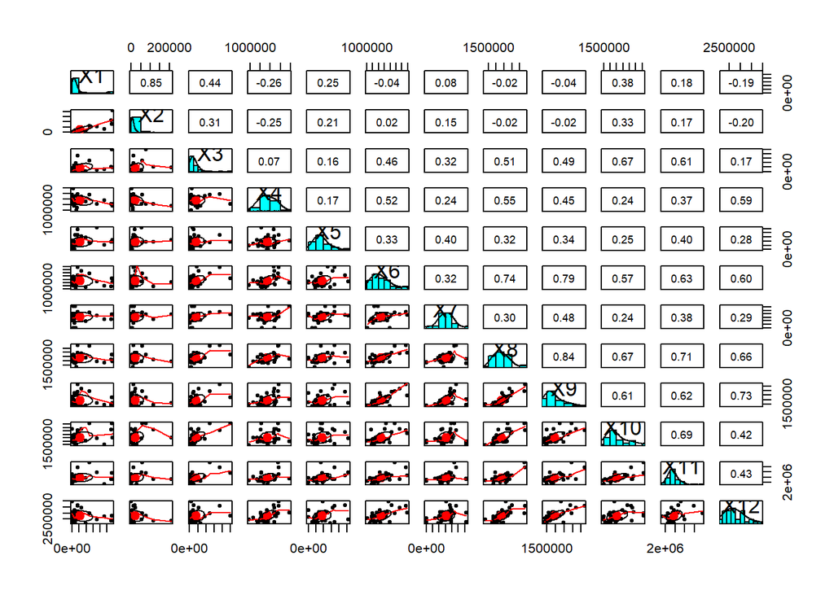

```r
library(corrplot)
pairs.panels(data1)
```

Dari output dan visualisasi diatas dapat dilihat bahwa ada beberapa nilai korelasi yang diatas 0.70 sehingga terjadi multikolinearitas dalam data tersebut. Untuk mengatasi masalah multikolinearitas maka akan melakukan dengan metode *Principal Component Analysis* (PCA)

# *Principal Component Analysis*

### Uji Asumsi KMO

Asumsi yang harus dipenuhi dalam PCA adalah kecukupan data. Uji kecukupan dalam analisis ini menggunakan uji Kasier Kayer Olkin (KMO). Sedangkan uji korelasi yang digunakan untuk mengetahui apakah terdapat hubungan antar variabel adalah uji Barrlett

```r
kmo <- function(x)
{
  x <- subset(x, complete.cases(x)) # Omit missing values
  r <- cor(x) # Correlation matrix
  r2 <- r^2 # Squared correlation coefficients
  i <- solve(r) # Inverse matrix of correlation matrix
  d <- diag(i) # Diagonal elements of inverse matrix
  p2 <- (-i/sqrt(outer(d, d)))^2 # Squared partial correlation coefficients
  diag(r2) <- diag(p2) <- 0 # Delete diagonal elements
  KMO <- sum(r2)/(sum(r2)+sum(p2))
  MSA <- colSums(r2)/(colSums(r2)+colSums(p2))
  return(list(KMO=KMO, MSA=MSA))
}

kmo(df)
```

```
## $KMO
## [1] 0.7575374
##
## $MSA
##        X1        X2        X3        X4        X5        X6        X7
## 0.5197883 0.5365243 0.7269696 0.7117780 0.6705074 0.8258363 0.5692724
##        X8        X9       X10       X11       X12
## 0.8237123 0.7636891 0.9128848 0.8917582 0.8574514
```

Diketahui nilai KMO adalah 0.758 atau 75.5% sehingga data telah cukup untuk melakukan analisis faktor. Nilai MSA untuk seluruh variabel bebas diatas 0.5 sehingga analisis faktor dapat dilakukan.

```r
Bartlett.spher.test <- function(x)
{
  method <- "Bartlett's test of sphericity"
  data.name <- deparse(substitute(x))
  x <- subset(x, complete.cases(x)) # Omit missing values
  n <- nrow(x)
  p <- ncol(x)
  chisq <- (1-n+(2*p+5)/6)*log(det(cor(x)))
  df <- p*(p-1)/2
  p.value <- pchisq(chisq, df, lower.tail=FALSE)
  names(chisq) <- "X-squared"
  names(df) <- "df"
  return(structure(list(statistic=chisq, parameter=df, p.value=p.value,
                        method=method, data.name=data.name), class="htest"))
}
Bartlett.spher.test(df)
```

```
##
##  Bartlett's test of sphericity
##
## data:  df
## X-squared = 253.69, df = 66, p-value < 2.2e-16
```

Ditunjukkan juga nilai P-value Barltlett test didapatkan sebesar 0.000 yang sangat kecil dari taraf signifikan sebesar 0.05, dari pernyataan tersebut dapat diputuskan menolak H<sub>0</sub> sehingga dapat disimpulkan untuk dilanjutkan analisis berikutnya.

## *Principal Component Analysis*

Analisis komponen utama digunakan untuk mengelompokkan variabel-variabel yang memiliki korelasi yang tinggi. Berikut adalah analisis dan pembahasan untuk analisis komponen utama.

#### Visualisasi Plot

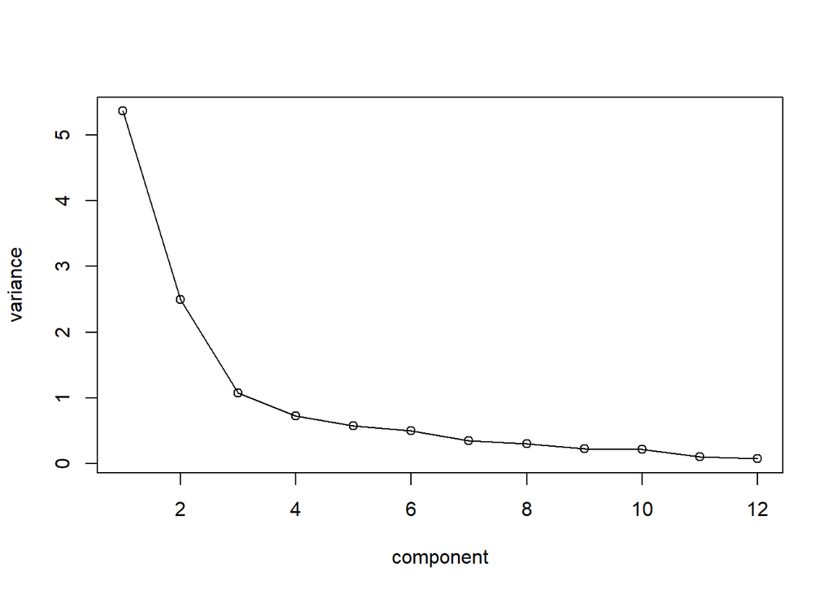

```r
plot(eigen(cor(df))$value,ylab = "variance", xlab = "component")
lines(eigen(cor(df))$values,)
```

#### Penentuan jumlah komponen berdasarkan *eigen value*

```r
pc <- prcomp(df,
             center = T,
             scale. = T)
summary(pc)
```

```
## Importance of components:
##                           PC1    PC2     PC3     PC4     PC5     PC6
## Standard deviation     2.3148 1.5779 1.03675 0.85112 0.75841 0.70517
## Proportion of Variance 0.4465 0.2075 0.08957 0.06037 0.04793 0.04144
## Cumulative Proportion  0.4465 0.6540 0.74359 0.80396 0.85189 0.89333
##                            PC7     PC8     PC9    PC10    PC11    PC12
## Standard deviation     0.59304 0.55487 0.47316 0.46674 0.32045 0.27585
## Proportion of Variance 0.02931 0.02566 0.01866 0.01815 0.00856 0.00634
## Cumulative Proportion  0.92263 0.94829 0.96695 0.98510 0.99366 1.00000
```

#### Mengambil 3 komponen baru

```r
pca <- round(pc$x[,1:3],3)
head(pca)
```

```
##                     PC1    PC2    PC3
## Aceh             -2.018  0.361 -0.086
## Sumatera Utara   -1.945  0.368 -0.521
## Sumatera Barat   -1.287  1.086 -0.301
## Riau              0.567  0.378 -0.043
## Jambi            -0.732  0.153  0.079
## Sumatera Selatan -0.778 -0.416 -0.091
```

```r
data.baru1 <- cbind(df, cluster=km$cluster)
klaster <- data.baru1[,13]
head(klaster)
```

```
##             Aceh   Sumatera Utara   Sumatera Barat             Riau
##                3                3                3                3
##            Jambi Sumatera Selatan
##                3                3
```

#### Mengabungan data PCA dan data Cluster

Menggabungan PCA dan Cluster dengan membuat data frame baru untuk analisis diskriminan

```r
dsk <- cbind(pca,klaster)
head(dsk)
```

```
##                     PC1    PC2    PC3 klaster
## Aceh             -2.018  0.361 -0.086       3
## Sumatera Utara   -1.945  0.368 -0.521       3
## Sumatera Barat   -1.287  1.086 -0.301       3
## Riau              0.567  0.378 -0.043       3
## Jambi            -0.732  0.153  0.079       3
## Sumatera Selatan -0.778 -0.416 -0.091       3
```

# ANALISIS DISKRIMINAN

```r
data.disk <- as.data.frame(dsk)
attach(data.disk)
```

#### Data Untuk Analisis Diskriminan

```r
datatable(data.disk)
```

|  | PC1 | PC2 | PC3 | klaster |
| --- | --- | --- | --- | --- |
| Aceh | -2.018 | 0.361 | -0.086 | 3 |
| Sumatera Utara | -1.945 | 0.368 | -0.521 | 3 |
| Sumatera Barat | -1.287 | 1.086 | -0.301 | 3 |
| Riau | 0.567 | 0.378 | -0.043 | 3 |
| Jambi | -0.732 | 0.153 | 0.079 | 3 |
| Sumatera Selatan | -0.778 | -0.416 | -0.091 | 3 |
| Bengkulu | -2.87 | 0.236 | -1.305 | 3 |
| Lampung | -2.212 | -0.392 | -1.027 | 3 |
| Kepulauan Babel | -0.339 | 1.153 | -0.189 | 3 |
| Kepulauan Riau | 2.761 | 0.632 | 0.06 | 1 |

[output cut: 24 more lines]

### Melihat Struktur data

Dalam analisis diskriminan variabel dependen(Y) harus kategori(non metrik). untuk melihat struktur bisa

```r
str(data.disk)
```

```
## 'data.frame':    34 obs. of  4 variables:
##  $ PC1    : num  -2.018 -1.945 -1.287 0.567 -0.732 ...
##  $ PC2    : num  0.361 0.368 1.086 0.378 0.153 ...
##  $ PC3    : num  -0.086 -0.521 -0.301 -0.043 0.079 ...
##  $ klaster: num  3 3 3 3 3 3 3 3 3 1 ...
```

Dari output diatas variavel Y (klaster), Software R baca numerik. oleh karena itu harus mengubah struktur datanya. berikut adalah caranya.

```r
data.disk$klaster <- as.factor(data.disk$klaster)
str(data.disk)
```

```
## 'data.frame':    34 obs. of  4 variables:
##  $ PC1    : num  -2.018 -1.945 -1.287 0.567 -0.732 ...
##  $ PC2    : num  0.361 0.368 1.086 0.378 0.153 ...
##  $ PC3    : num  -0.086 -0.521 -0.301 -0.043 0.079 ...
##  $ klaster: Factor w/ 3 levels "1","2","3": 3 3 3 3 3 3 3 3 3 1 ...
```

Dapat dilihat bahwa variabel Y (klaster) sudah jadi variabel kategori.

library untuk analisis diskriminan

```r
library(psych)
library(MASS)
```

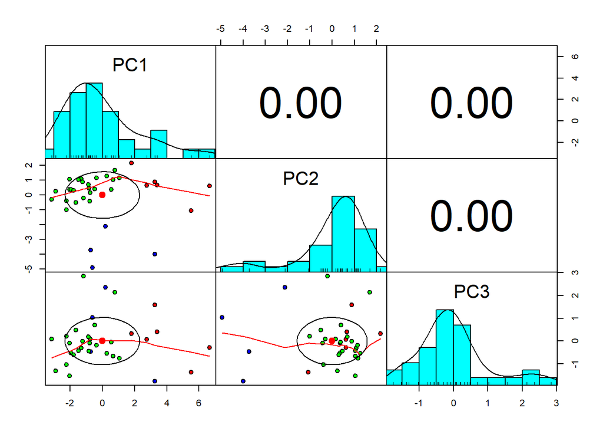

```r
pairs.panels(data.disk[1:3],
             gap=0,
             bg=c("red","blue","green")[data.disk$klaster],
             pch = 21)
```

Plot diatas menunjukkan bahwa antara variabel bebas memiliki nilai korelasi 0 sehingga tidak terjadi multikolinearitas.

```r
library(biotools)
boxM(data.disk[,1:3], data.disk$klaster)
```

```
##
##  Box's M-test for Homogeneity of Covariance Matrices
##
## data:  data.disk[, 1:3]
## Chi-Sq (approx.) = 20.103, df = 12, p-value = 0.06516
```

## Data Partisi

Data partisi yang dimaksud disini adalah membuat data training dan data testing. data training digunakan untuk membuat model diskriminan sedangkan data testing digunakan untuk mengvaldasi model atau sejauh mana model tersebut bisa digunakan untuk memprediksi kasus baru. Karena data sampel terlalu kecil sehingga data disini saya ambil data random 80% dari data untuk training sedangkan 20% untuk testing. berikut adalah hasilnya

```r
set.seed(222)
ind <- sample(2, nrow(data.disk),
              replace = T,
              prob = c(0.8,0.2))

training <- data.disk[ind==1,]
testing <- data.disk[ind==2,]
```

### Model Diskriminan

```r
model <- lda(klaster ~., data = training)
model
```

```
## Call:
## lda(klaster ~ ., data = training)
##
## Prior probabilities of groups:
##         1         2         3
## 0.2222222 0.1111111 0.6666667
##
## Group means:
##          PC1        PC2       PC3
## 1  3.9003333  0.6483333 0.1158333
## 2  0.9126667 -3.2846667 0.0430000
## 3 -1.0040000  0.5270556 0.0065000
##
## Coefficients of linear discriminants:
##            LD1         LD2
## PC1  0.2411362 -0.65370141
## PC2 -1.3515285 -0.39987254
## PC3  0.3603853 -0.02730538
##
## Proportion of trace:
##    LD1    LD2
## 0.6163 0.3837
```

Output diatas menunjukkan model diskriminan yang ditunjukkan pada *Coefficients of linear discriminants*. Model untuk LD1:

First discriminant function is a linear combination of three variables (PC1, PC2, PC3)

Fungsi diskriminan dapat ditulis sebagai berikut

LD1 = 0.2411362 PC1 - 1.3515285PC2 + 0.3603853 PC3

Model diatas dapat diinterpretasi bahwa variabel PC1 dan PC3 memiliki yang positif dan searah dengan fungsi diskriminan. Jika PC1 dan PC3 naik satu satuan maka akan menaikan fungsi diskriminan sedangkan PC2 memiliki koefesien yang negatif artinya variabel PC2 naik maka akan menerunkan nilai skor diskriminan.

#### Bi-plot

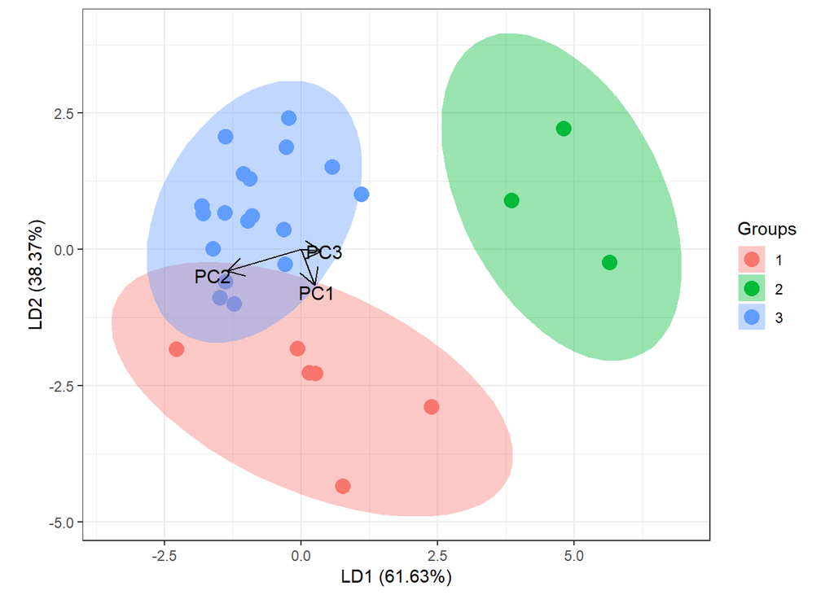

```r
library(devtools)
library(ggord)
ggord(model, training$klaster)
```

Bi-plot diatas membantu kita untuk memahami fungsi diskriminan yang terbentuk. Terlihat bahwa pada Fungsi LD1 variabel PC1 dan PC3 berada pada daerah positif sedangkan PC2 berada pada daerah negatif. Pada fungsi LD2 terlihat bahwa PC1, PC2 dan PC3 berada pada daerah yang negatif.

#### Confusion Matrix and Accuracy untuk data training

```r
p.training <- predict(model, training)$class
tabel.training <- table(Actual = training$klaster, predicted =  p.training)
tabel.training
```

```
##       predicted
## Actual  1  2  3
##      1  5  0  1
##      2  0  3  0
##      3  0  0 18
```

Terlihat bahwa hanya ada satu data yang salah klasifikasi. Data tersebut awalnya masuk klaster 1 tetapi model diskriminan prediksi masuk klaster 3.

#### Accuracy data training

```r
sum(diag(tabel.training))/sum(tabel.training)
```

```
## [1] 0.962963
```

```r
p.testing <- predict(model, testing)$class
tabel.testing <- table(Actual = testing$klaster, predicted =  p.testing)
tabel.testing
```

```
##       predicted
## Actual 1 2 3
##      1 0 0 0
##      2 0 1 0
##      3 0 0 6
```

#### Accuracy data testing

```r
sum(diag(tabel.testing))/sum(tabel.testing)
```

```
## [1] 1
```

Terlihat bahwa akurasi untuk data testing sebesar 100%.